# Linear Regression I

John Ashley Burgoyne

This tutorial assumes that you have loaded the chopsticks dataset into R.

## Loading **rstanarm**

### Install the Package [one time only]

If you have not yet already, install the **rstanarm** package. You only need to do this once.

1. From the Tools menu in RStudio, choose Install Packages. A new window should open in the middle of your screen.
2. Type `rstanarm` into the Packages box of the new window.
3. Make sure that the Install Dependies checkbox is **checked**.
4. Click on the Install button.

### Load the Package [every time]

Every time you load RStudio and you want to do linear regression, you need to tell R to load **rstanarm**. You do that with the `library()` command.

```r
library(rstanarm)
```

## Running a Regression

In the chopsticks experiment, participates rated music on a number of different scales. Let’s try to predict how likely it would be that they would recommend a piece of music to a friend (`chopsticks$recommend`, scale of 1–10) on the basis of how much they liked the song (`chopsticks$liked`, scale of 1–10).

### Step 1. Look at your data.

Let’s start by making a scatter plot. It does look like there is a relationship between the two types of ratings.

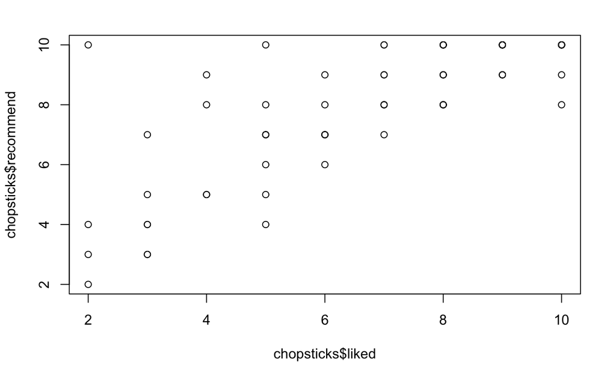

### Step 2. Choose a model.

For us, this is always linear regression. Load the **rstanarm** package using the code above in order to get the best tools to run a linear regression.

### Step 3. Fit the model.

We can fit linear regressions using the `stan_glm()` command. (GLM stands for *generalised linear model*, because it can do much more than just linear regression, and it uses a program called Stan to run simulations.)

First, fit the model using the command as follows. The dependent variable always goes on the left side of the tilde (`~`), and the predictor always goes on the right side.

This command automatically runs 2000 simulations for you, using very simple Bayesian prior information that we don’t expect extremely large positive or negative parameter values.

```r
fit <- stan_glm(chopsticks$recommend ~ chopsticks$liked)
```

[output not shown]

### Step 4. Understand the model fit.

We use the `print()` command to look at the output. Because we saved the fit as `fit` in the last step, we use the same name again now. You can choose how many decimal places you want to see, but 2 is traditional.

Remember that `stan_glm()` uses 2000 *random* simulations. Your results may be very slightly different than what you see below, but the differences should be small.

```r
print(fit, 2)
```

```
stan_glm
 family:       gaussian [identity]
 formula:      chopsticks$recommend ~ chopsticks$liked
 observations: 69
 predictors:   2
------
                 Median MAD_SD
(Intercept)      3.15   0.50
chopsticks$liked 0.71   0.07

Auxiliary parameter(s):
      Median MAD_SD
sigma 1.40   0.12

------
* For help interpreting the printed output see ?print.stanreg
* For info on the priors used see ?prior_summary.stanreg
```

For each parameter, we get the median parameter value – a robust alternative to the mean – and the MAD SD – a robust alternative to the standard error (SE). The authors of `stan_glm()` prefer to use these robust alternatives because random simulations mean that there is always a risk of outliers.

The slope parameter will be given the name of the predictor: a slope of 0.71 for `liked` in this case. We can compute credible intervals using the MAD SD: 0.07 in this case.

A 95% credible interval is the median ±2 MAD SD. So we can be 95% sure that the true slope in this model is between 0.57 and 0.85.

```r
0.71 - 2 * 0.07
```

```
[1] 0.57
```

```r
0.71 + 2 * 0.07
```

```
[1] 0.85
```

### Step 5. Identify flaws and questionable assumptions.

Finally, we can use the `abline()` command to add the regression line to our scatterplot from before. We want to use our median intercept and median slope to draw the line. It looks like the reliability is actually not that good, and there is a noticeable outlier where the liked rating was 2 but the recommend rating was 10.

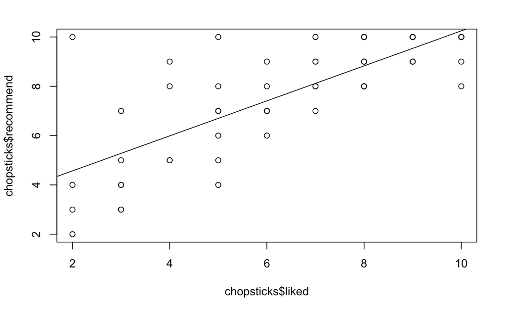

```r
plot(chopsticks$liked, chopsticks$recommend)
abline(3.15, 0.71)
```

## Recommended Exercises

- Try running your own regression using the chopsticks data, any of the other data sets from the course, or your own data. Compute a 95% credible interval for the slope parameter and explain in your own words what you think the results mean.